# Marine Trade in Africa

Part 1: Visuals

Roman Rakov

11/24

```r
library(sf)
library(tidyr)
library(dplyr)
library(ggplot2)
library(rnaturalearth)
library(htmltools)
library(pdynmc)
library(purrr)
library(broom)
library(patchwork)
```

```r
# setwd("M:\Student\Rakov\Tasks Kyra")
dist_df <- readRDS("cities_close_to_ports.rds")
city_df <- readRDS("city_lights_monthly.rds")
port_df <- readRDS("port_lights_monthly.rds")
etno_df <- readRDS("ethnic_geo_info_recent.rds")
```

## Explorative Data Analysis

Plot average monthly lights across all ports, using `port_df`:

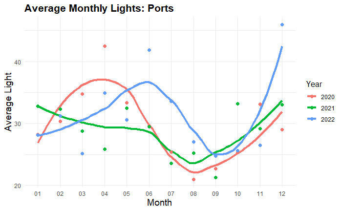

```r
# Calculate average light for each month in each year across all ports
temp_df <- port_df %>%
  group_by(year, month) %>%
  summarise(avg_light = mean(light, na.rm = TRUE)) %>%
  ungroup()
# Plot with smooth and bold lines
ggplot(temp_df, aes(x = month, y = avg_light, color = as.factor(year), group = year)) +
  geom_smooth(method = "loess", se = FALSE, size = 1.5) +
  geom_point(size = 2) +
  labs(
    title = "Average Monthly Lights: Ports",
    x = "Month",
    y = "Average Light",
    color = "Year"
  ) +
  theme_minimal() +
  theme(
    plot.title = element_text(size = 16, face = "bold"),
    axis.title = element_text(size = 14),
    legend.title = element_text(size = 12)
  )
```

Now, plot average monthly lights across all *non-port* cities:

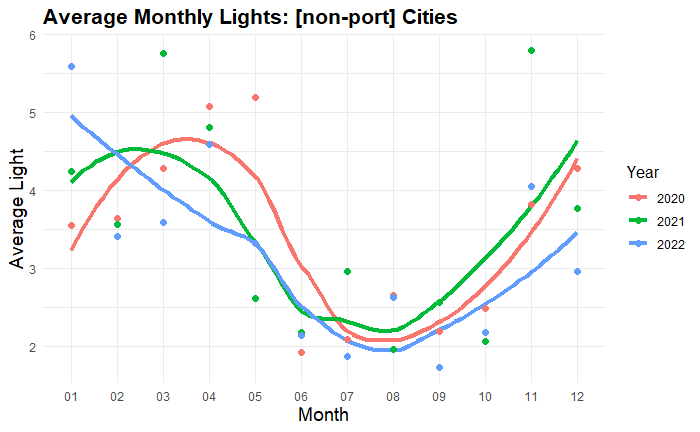

```r
temp_df <- city_df %>%
  left_join(dist_df %>% select(city_id, port_city), by = "city_id") %>%
  filter(port_city == "FALSE") %>%
  group_by(year, month) %>%
  summarise(avg_light = mean(light, na.rm = TRUE)) %>%
  ungroup()
ggplot(temp_df, aes(x = month, y = avg_light, color = as.factor(year), group = year)) +
  geom_smooth(method = "loess", se = FALSE, size = 1.5) +
  geom_point(size = 2) +
  labs(
    title = "Average Monthly Lights: [non-port] Cities",
    x = "Month",
    y = "Average Light",
    color = "Year"
  ) +
  theme_minimal() +
  theme(
    plot.title = element_text(size = 16, face = "bold"),
    axis.title = element_text(size = 14),
    legend.title = element_text(size = 12)
  )
```

**A few observations:**

- Cyclical pattern in both! Could it be explained by geographical location?

Next, let’s look at the average light intensity (across all time periods) for port and non-port cities:

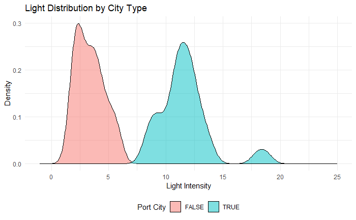

```r
temp_df <- city_df %>%
  left_join(dist_df %>% select(city_id, port_city), by = "city_id") %>%
  group_by(port_city, year, month) %>%
  summarise(avg_light = mean(light, na.rm = TRUE)) %>%
  ungroup()
# Create density plots for light distribution by type
ggplot(temp_df, aes(x = avg_light, fill = port_city)) +
  geom_density(alpha = 0.5) +
  xlim(-1, 25) +
  theme_minimal() +
  labs(
    title = "Light Distribution by City Type",
    x = "Light Intensity",
    y = "Density",
    fill = "Port City") +
  theme(legend.position = "bottom")
```

[Map](https://www.vox.com/2016/4/25/11503152/shipping-routes-map) of trading routes, **2012** (works only inside R studio, not in html!):

```r
html <- HTML('<iframe src="//www.shipmap.org" style="width: 100%; height: 600px; border: 0" frameborder="0"></iframe>
<div style="width: 100%; font-size: 10px; margin-top: 4px">Created by <a target="_top" href="https://www.kiln.digital/">London-based data visualisation studio Kiln</a> and the <a target="_top" href="http://www.bartlett.ucl.ac.uk/energy">UCL Energy Institute</a></div>')

# Display the HTML content
browsable(html)
```

[interactive chart not shown]

Created by [London-based data visualisation studio Kiln](https://www.kiln.digital/) and the [UCL Energy Institute](http://www.bartlett.ucl.ac.uk/energy)

## Map Centroids to Countries

**Issue**: some cities in the dataset are outside the African map. I delete them:

```r
# Find most east cities:
# most_right_point <- dist_df %>%
#   mutate(x_coord = st_coordinates(geom)[, 1]) %>%
#   slice_max(order_by = x_coord, n = 5)
#
# print(most_right_point)

# Delete cities and Convert geometries to points
temp_df <- dist_df %>%
  filter(!city_id %in% c(22453, 22451, 22452, 22450)) %>%
  mutate(geom = st_centroid(geom))
```

Match country name based on its cities location:

```r
# Reproject the 'dist_sf' geometry
africa <- ne_countries(scale = "medium", continent = "Africa", returnclass = "sf")
city_point <- st_transform(temp_df, st_crs(africa))

# Convert 'city_point' to an sf object
city_point_sf <- st_sf(geometry = city_point)

# Perform the spatial join to add country names
matched <- st_join(city_point_sf, africa["sovereignt"]) %>%
  rename(name = sovereignt)
```

**Issue**: some points and polygons are mismatched. Do not add a buffer! Horrible idea! Messes up the labels, same `city_id` can be in two countries!

Apply the brute force (assign labels by the closest neighbor):

```r
# Identify points with NA after spatial join
na_points <- matched[is.na(matched$name), ]

# Find the nearest country for each NA point
nearest_country <- st_nearest_feature(na_points, africa)

# Assign the name of the nearest country to these points
na_points$name <- africa$name[nearest_country]

# Combine the updated NA points back with the original matched dataset
matched$name[is.na(matched$name)] <- na_points$name
```

A sanity check if points from one country are located where they should be. Seems to be working:

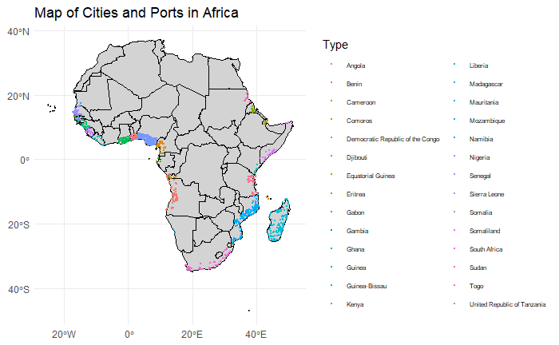

```r
# plot_df <- matched %>%
#   filter(name %in% c("Senegal"))

# Plotting the map with larger points and Africa as background
plot <- ggplot() +
  geom_sf(data = africa, fill = "lightgray", color = "black") +
  geom_sf(data = matched, aes(color = name), size = 0.2, shape = 16) +  # Adjust size and shape here
  theme_minimal() +
  labs(title = "Map of Cities and Ports in Africa",
       color = "Type") +
  theme(legend.position = "right",
        legend.text = element_text(size = 6)
)

print(plot)
```

```r
# ggsave("combined_plot.pdf", plot = plot, width = 8, height = 6)
```

## Removing seasonality?

Seasonality inflates correlation estimates:

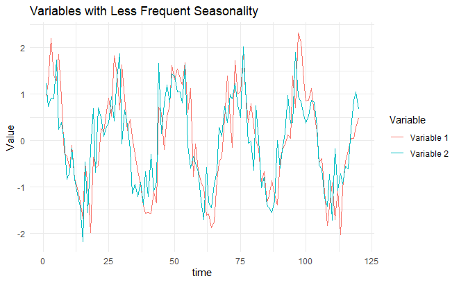

```r
set.seed(123)

# Generate data
n <- 120
time <- 1:n

seasonality1 <- sin(2 * pi * time / 24) + cos(2 * pi * time / 24)
seasonality2 <- 0.8 * sin(2 * pi * time / 24 + pi / 4) + 0.5 * cos(2 * pi * time / 24)

noise1 <- rnorm(n, mean = 0, sd = 0.5)
noise2 <- rnorm(n, mean = 0, sd = 0.5)

var1 <- seasonality1 + noise1
var2 <- seasonality2 + noise2
data <- data.frame(time = time, var1 = var1, var2 = var2)

# Remove seasonality using regression
data$var1_detrended <- lm(var1 ~ sin(2 * pi * time / 24) + cos(2 * pi * time / 24), data = data)$residuals
data$var2_detrended <- lm(var2 ~ sin(2 * pi * time / 24) + cos(2 * pi * time / 24), data = data)$residuals

plot1 <- ggplot(data, aes(x = time)) +
  geom_line(aes(y = var1, color = "Variable 1")) +
  geom_line(aes(y = var2, color = "Variable 2")) +
  labs(title = "Variables with Less Frequent Seasonality", y = "Value", color = "Variable") +
  theme_minimal()

plot2 <- ggplot(data, aes(x = time)) +
  geom_line(aes(y = var1_detrended, color = "Variable 1")) +
  geom_line(aes(y = var2_detrended, color = "Variable 2")) +
  labs(title = "Variables without Seasonality (Detrended)", y = "Value", color = "Variable") +
  theme_minimal()

print(plot1)
```

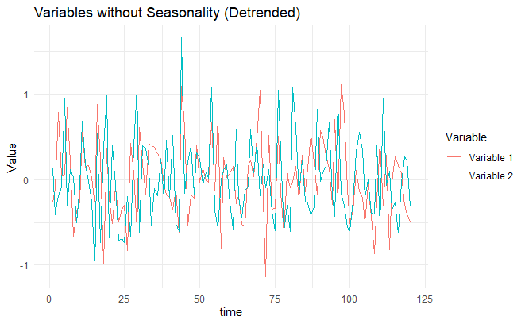

```r
print(plot2)
```

There are different ways to approach this:

1. Decompose Seasonality for Each City/Port Separately
2. Compute an Aggregated Seasonal Trend Across All Countries

Let’s do both and see the result. Just a single city as an example:

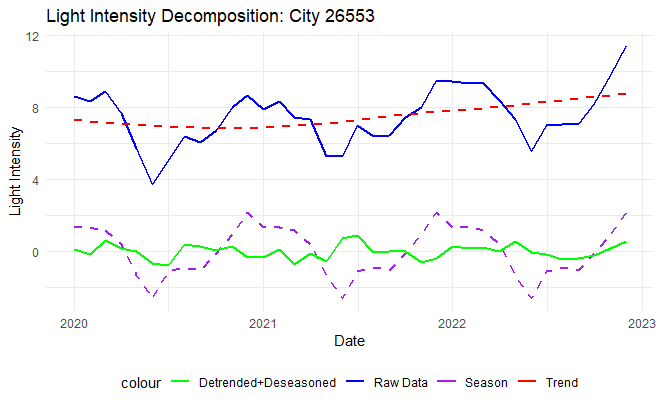

```r
# Combine year and month into a Date column
data <- city_df[city_df$city_id == "26553", c("year","month","light")] %>%
  mutate(date = as.Date(paste(year, month, "01", sep = "-")))

# Apply STL  to remove seasonality (for a single city/port in this case)
ts_data <- ts(data$light, frequency = 12)
decomposed <- stl(ts_data, s.window = "periodic")

# Extract the components (trend, seasonal, residuals)
trend     <- decomposed$time.series[, "trend"]
seasonal  <- decomposed$time.series[, "seasonal"]
residuals <- decomposed$time.series[, "remainder"]

data <- data %>%
  mutate(trend = trend,
         seasonal = seasonal,
         residuals = residuals)

ggplot(data) +
  geom_line(aes(x = date, y = light, color = "Raw Data", linetype = "Solid"), size = 1) +
  geom_line(aes(x = date, y = trend, color = "Trend", linetype = "Dashed"), size = 1) +
  geom_line(aes(x = date, y = seasonal, color = "Season", linetype = "Dashed"), size = 1) +
  geom_line(aes(x = date, y = residuals, color = "Detrended+Deseasoned", linetype = "Solid"), size = 1) +
  labs(
    title = paste("Light Intensity Decomposition: City", 26553),
    x = "Date",
    y = "Light Intensity") +
  theme_minimal() +
  theme(legend.position = "bottom") +
  scale_color_manual(values = c("Raw Data" = "blue", "Trend" = "red", "Season" = "purple", "Detrended+Deseasoned" = "green")) +
  scale_linetype_manual(values = c("Solid" = "solid", "Dashed" = "dashed", "Dotted" = "dotted")) + guides(linetype = "none")
```

Another extreme: computing overall season across all cities/ports in all countries

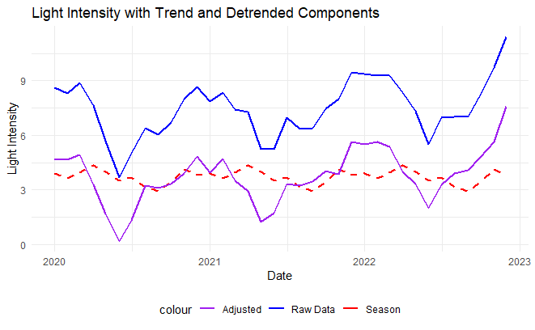

```r
# Combine year and month into a Date column
data <- city_df[, c("city_id","year","month","light")] %>%
  mutate(date = as.Date(paste(year, month, "01", sep = "-")))

# Aggregate light intensity by month across all cities/ports
aggregated_seasonal <- data %>%
  group_by(month) %>%
  summarize(avg_light = mean(light, na.rm = TRUE))

# Join the aggregated seasonal pattern back to the original data
data <- data %>%
  left_join(aggregated_seasonal, by = "month") %>%
  mutate(seasonally_adjusted = light - avg_light)

ggplot(data[data$city_id == "26553", ]) +
  geom_line(aes(x = date, y = light, color = "Raw Data", linetype = "Solid"), size = 1) +
  geom_line(aes(x = date, y = avg_light, color = "Season", linetype = "Dashed"), size = 1) +
  geom_line(aes(x = date, y = seasonally_adjusted, color = "Adjusted", linetype = "Solid"), size = 1) +
  labs(
    title = "Light Intensity with Trend and Detrended Components",
    x = "Date",
    y = "Light Intensity"
  ) +
  theme_minimal() +
  theme(legend.position = "bottom") +
  scale_color_manual(values = c("Raw Data" = "blue", "Season" = "red", "Adjusted" = "purple")) +
  scale_linetype_manual(values = c("Solid" = "solid", "Dashed" = "dashed", "Dotted" = "dotted")) + guides(linetype = "none")
```

Seasonal trend is too smooth, essentially demeaning the data. Need to be more granular. Going country-wise?

How much seasonality do we actually have? Sample random cities and plot the pattern:

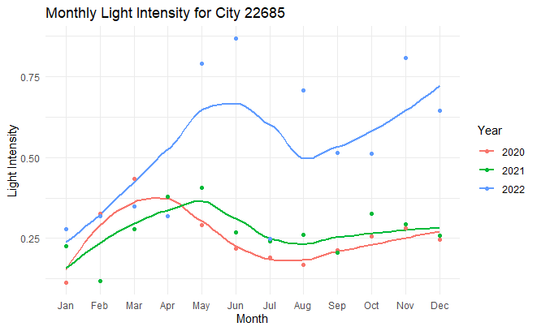

```r
city_id_to_plot <- sample(city_df$city_id, size = 1)

plot <- ggplot(city_df[city_df$city_id == city_id_to_plot, c("year","month","light")], aes(x = factor(month), y = light, color = factor(year), group = year)) +
  geom_smooth(se = FALSE, method = "loess") +
  geom_point() +
  labs(
    title = paste("Monthly Light Intensity for City", sample(city_df$city_id, size = 1)),
    x = "Month",
    y = "Light Intensity",
    color = "Year"
  ) +
  theme_minimal() +
  scale_x_discrete(labels = c("Jan", "Feb", "Mar", "Apr", "May", "Jun",
                              "Jul", "Aug", "Sep", "Oct", "Nov", "Dec"))

print(plot)
output_path <- paste0("M:/Student/Rakov/Tasks Kyra/Cities/city_", city_id_to_plot, ".pdf")
ggsave(output_path, plot = plot, width = 10, height = 6)
```

How does the country seasonality look like? Save them all:

```r
# get the data ready
data <- city_df %>%
  left_join(
    matched %>% select(city_id, name),
    by = "city_id"
  ) %>%
  drop_na() %>%
  ungroup()
# Calculate mean monthly light
temp_df <- data %>%
  group_by(name, year, month) %>%
  summarise(mean_light = mean(light, na.rm = TRUE), .groups = 'drop') %>%
  select(name, year, month, mean_light)


# Get unique list of countries
countries <- unique(temp_df$name)

for (country in countries) {

  plot <- ggplot(temp_df[temp_df$name == country, c("year","month","mean_light")], mapping = aes(x = factor(month), y = mean_light, color = factor(year), group = year)) +
    geom_smooth(se = FALSE, method = "loess") +
    geom_point() +
    labs(
     title = paste("Monthly Light Intensity for", country),
     x = "Month",
     y = "Light Intensity",
     color = "Year"
   ) +
   theme_minimal() +
   scale_x_discrete(labels = c("Jan", "Feb", "Mar", "Apr", "May", "Jun",
                              "Jul", "Aug", "Sep", "Oct", "Nov", "Dec"))

  # Save the plot to the specified directory
  output_path <- paste0("M:/Student/Rakov/Tasks Kyra/Countries/", country, ".pdf")
  # output_path <- paste0("/Users/romanrakov/Desktop/ifo Dresden/Kyra/R/Bounds/", country, ".pdf")
  ggsave(output_path, plot = plot, width = 10, height = 6)
}
```

There is no clear guidance on how to proceed. The most conservative would be to include city “*fixed effects*” (metaphorically speaking) by removing the season (estimated based on 3 years) from each city individually.

## Summarizing Light Intensity

One commonly used measure is the **ratio of seasonal variance to total variance**, which captures how much of the variability in light intensity is explained by seasonal fluctuations.

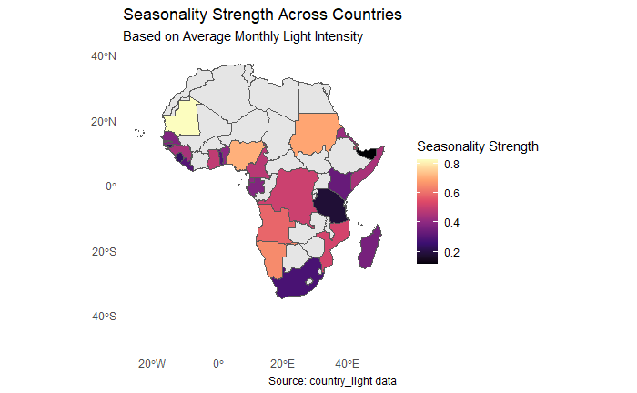

```r
# Calculate average light intensity by year, month, and distance bin
country_light <- data %>%
  group_by(name, year, month) %>%
  summarise(avg_light = mean(light, na.rm = TRUE), .groups = 'drop')

# Step 1: Define function to calculate seasonality strength
calculate_seasonality_strength <- function(light_intensity) {
  ts_data <- ts(light_intensity, frequency = 12)  # Monthly data (12 periods per year)
  decomposition <- stl(ts_data, s.window = "periodic")  # STL decomposition
  seasonal_var <- var(decomposition$time.series[, "seasonal"], na.rm = TRUE)
  total_var <- var(light_intensity, na.rm = TRUE)
  strength <- seasonal_var / total_var
  return(strength)
}

# Step 2: Apply the function to each country
seasonality_summary <- country_light %>%
  group_by(name) %>%
  summarise(seasonality_strength = calculate_seasonality_strength(avg_light)) %>%
  ungroup()

# Step 3: Merge seasonality data with spatial data
africa <- africa  %>%
  left_join(seasonality_summary, by = c("sovereignt" = "name"))

# Step 4: Plot the map
ggplot(africa) +
  geom_sf(aes(fill = seasonality_strength)) +
  scale_fill_viridis_c(option = "magma", na.value = "grey90", name = "Seasonality Strength") +
  theme_minimal() +
  labs(
    title = "Seasonality Strength Across Countries",
    subtitle = "Based on Average Monthly Light Intensity",
    caption = "Source: country_light data"
  ) +
  theme(
    legend.position = "right",
    panel.grid = element_blank()
  )
```

Now, consider different mean light across time for each country and its respective GDP:

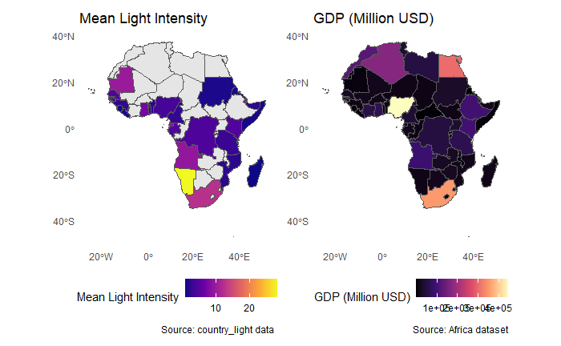

```r
# Step 1: Calculate mean light intensity for each country
light_summary <- country_light %>%
  group_by(name) %>%
  summarise(mean_light = mean(avg_light, na.rm = TRUE)) %>%
  ungroup()

# Step 2: Merge with GDP and light intensity
africa <- ne_countries(continent = "Africa", scale = "medium", returnclass = "sf") %>%
  left_join(light_summary, by = c("sovereignt" = "name"))

# Step 3: Create the heatmap for mean light intensity
plot1 <- ggplot(africa) +
  geom_sf(aes(fill = mean_light)) +
  scale_fill_viridis_c(option = "plasma", na.value = "grey90", name = "Mean Light Intensity") +
  theme_minimal() +
  labs(
    title = "Mean Light Intensity",
    caption = "Source: country_light data"
  ) +
  theme(
    legend.position = "bottom",
    panel.grid = element_blank())

# Step 4: Create the heatmap for GDP
plot2 <- ggplot(africa) +
  geom_sf(aes(fill = gdp_md)) +
  scale_fill_viridis_c(option = "magma", na.value = "grey90", name = "GDP (Million USD)") +
  theme_minimal() +
  labs(
    title = "GDP (Million USD)",
    caption = "Source: Africa dataset"
  ) +
  theme(
    legend.position = "bottom",
    panel.grid = element_blank())

combined_plot <- plot1 + plot2 + plot_layout(ncol = 2)
print(combined_plot)
```

## Ethnicities

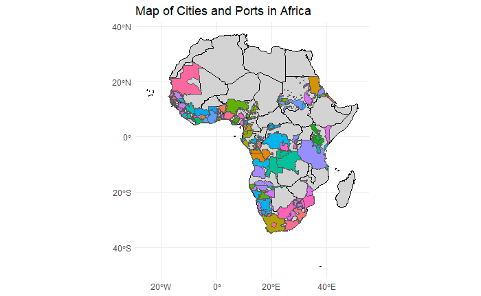

```r
# Plotting the map with larger points and Africa as background
plot <- ggplot() +
  geom_sf(data = africa, fill = "lightgray", color = "black") +
  geom_sf(data = etno_df, aes(fill = group), size = 0.5, shape = 16) +
  theme_minimal() +
  labs(title = "Map of Cities and Ports in Africa",
       color = "group") +
  theme(legend.position = "none")

print(plot)
```

```r
# ggsave("raw_etno_plot.pdf", plot = plot, width = 8, height = 6)
```

Match **ethnicity** based on the cities’ location:

```r
temp_df <- dist_df %>%
  filter(!city_id %in% c(22453, 22451, 22452, 22450)) %>%
  mutate(geom = st_centroid(geom))

city_point <- st_transform(temp_df, st_crs(etno_df$geometry))
city_point_sf <- st_sf(geometry = city_point)
matched <- st_join(city_point_sf, etno_df["group"]) %>%
  mutate(is_na = ifelse(is.na(group), "NA", "Not NA"))
```

```r
# Plot 1: Map with larger points
plot1 <- ggplot() +
  geom_sf(data = africa, fill = "lightgray", color = "black") +
  geom_sf(data = matched, aes(color = group), size = 0.2, shape = 16) +
  theme_minimal() +
  labs(title = "Cities Matched to Ethnicities",
       color = "Type") +
  theme(legend.position = "none")

# Plot 2: Map with NA highlighting
plot2 <- ggplot() +
  geom_sf(data = africa, fill = "lightgray", color = "black") +
  geom_sf(data = matched, aes(color = is_na, shape = is_na)) +
  scale_color_manual(values = c("Not NA" = "blue", "NA" = "red")) +  # Red for NA values
  scale_shape_manual(values = c("Not NA" = 16, "NA" = 17)) +  # Change shape for NA values
  theme_minimal() +
  labs(title = "NA (red) and non-NA  Matches",
       color = "Type") +
  theme(legend.position = "none")

# Combine the plots into a single figure with two subplots
combined_plot <- plot1 + plot2 + plot_layout(ncol = 2)  # Arrange vertically
```

[output not shown]

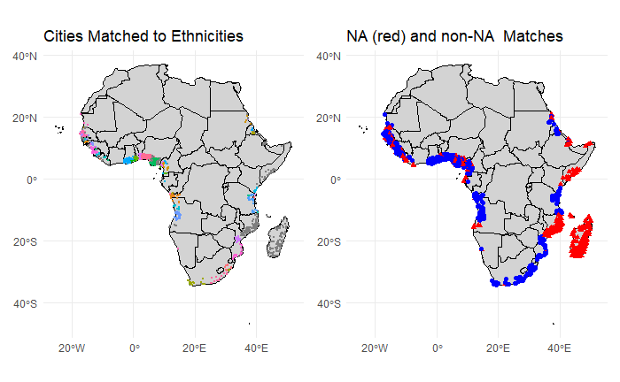

```r
# Display the combined plot
print(combined_plot)
```

```r
# Save the combined plot
# ggsave("combined_etno_plot.pdf", plot = combined_plot, width = 8, height = 12)
```